# Exercise 3

Fortgeschrittene Statistische Software für NF

Megi Bida, 12797612  
2025-06-06

## General Remarks

- You can submit your solutions in teams of up to 3 students.
- Include all your team-member’s names and student numbers (Matrikelnummern) in the `authors` field.
- Please use the exercise template document to work on and submit your results.
- Use a level 2 heading for each new exercise and answer each subtask next to its bullet points or use a new level 3 heading if you want.
- Always render the R code for your solutions (`echo=TRUE`) and make sure to include the resulting data in your rendered document.
  - Make sure to not print more than 10 rows of data (unless specifically instructed to).
- Always submit both the rendered document(s) as well as your source Rmarkdown or Quarto document. Submit the files separately on moodle, **not** as a zip archive.
- Submission format is HTML. Other formats will lead to a deduction of points.

## Exercise 1: Initializing git (4 Points)

For this whole exercise sheet we will be tracking all our changes to it in git.

1. Start by initializing a new R project with git support, called `2025-exeRcise-sheet-3`. If you forgot how to do this, you can follow this [guide](https://malikaihle.github.io/Introduction-RStudio-Git-GitHub/rstudio_project.html).
2. Commit the files generated by Rstudio.
3. For all of the following tasks in this exercise sheet we ask you to always commit your changes after finishing each subtask e.g. create a commit after task *1d*, *1e* etc.

> Note: This applies only to answers that have text or code as their answer. If you complete tasks in a different order or forget to commit one, this is no problem. If you change your answers you can just create multiple commits to track the changes.
4. Name 2 strengths and 2 weaknesses of git. (Don’t forget to create a commit after this answer, see *1c*)

2 Strengths:  
Suitable for collaboration  
You can track the history and understand or revert changes when there are problems  
2 Weaknesses:  
Not good for storing data as it struggles with large files  
It can be complicated to use it at first (The commit for this task is called “Third commit”)

5. Knit this exercise sheet. Some new files will automatically be generated when knitting the sheet e.g. the HTML page. Ignore these files, as we only want to track the source files themselves. You can, but don’t need to create a `.gitignore` file. Just do not commit these files manually.

## Exercise 2: Putting your Repository on GitHub (3 Points)

For this task you will upload your solution to GitHub.

1. Create a new repository on GitHub in your account named `exeRcise-sheet-3`. Make sure you create a **public repository** so we are able to see it for grading. Add the link to the repository below:

   https://github.com/megib16/exeRcise-sheet-3.git
2. Push your code to this new repository by copying and executing the snippet on github listed under `…or push an existing repository from the command line`.
3. Regularly push your latest changes to GitHub again and especially do so when you are finished with this sheet.

## Exercise 3: Pixar Films (4 Points)

Download the `pixar_films` and `public_response` datasets from the GitHub repository and track them in git.

Link: https://github.com/rfordatascience/tidytuesday/tree/main/data/2025/2025-03-11

For small datasets like these adding them to git is not a problem.

1. Load the `pixar_films` dataset into R. Clean the dataset by removing films without a title. Inspect the variable `film_rating`. What are the possible values and what do they mean? Create a factor variable for the film rating. Why is this appropriate?

```r
library(tidyverse)
pixar_films<-read_csv("pixar_films.csv")
pixar_films_clean<-pixar_films %>%
  filter(!is.na(film))
pixar_films_clean$film_rating_factor <- factor(pixar_films_clean$film_rating,
                                               levels = c("G", "PG", "N/A"))
```

```
The possible values for film rating are:
G- it means: General audiences – All ages admitted
PG- it means: Parental guidance suggested – Some material may not be
suitable for children
N/A- the film has not been rated
Factors help R understand the values not like just strings,
but as categories. This allows for an easier use in summaries or if
we want to plot it.
```

2. Inspect the film titles manually. Which films form a film series? A film series can be identified by a common word in the titles of the films, often in conjunction with a number in the title, e.g. “Despicable Me” and “Despicable Me 2”. Create a dataframe which displays a list of the different series with the titles of the films and how many films belong to the series. Output the dataframe.

```r
pixar_series<-pixar_films_clean %>%
  mutate(series = case_when(
    grepl("Toy Story", film) ~ "Toy Story",
    grepl("Cars", film) ~ "Cars",
    grepl("Finding", film) ~ "Finding",
    grepl("Incredibles", film) ~ "Incredibles",
    grepl("Monsters", film) ~ "Monsters",
    TRUE ~ NA_character_
  ))

pixar_series_grouped <- pixar_series %>%
  filter(!is.na(series)) %>%
  group_by(series) %>%
  summarise(
    titles = paste(film,
                   collapse = ", "
                   ),
    num_films = n(),
    .groups = "drop"
  )
pixar_series_grouped
```

```
# A tibble: 5 × 3
  series      titles                                         num_films
  <chr>       <chr>                                              <int>
1 Cars        Cars, Cars 2, Cars 3                                   3
2 Finding     Finding Nemo, Finding Dory                             2
3 Incredibles The Incredibles, Incredibles 2                         2
4 Monsters    Monsters, Inc., Monsters University                    2
5 Toy Story   Toy Story, Toy Story 2, Toy Story 3, Toy Stor…         4
```

3. Load the `public_response` dataframe into R. Convert the `cinema_score` variable into a factor while ensuring the factor levels are defined in ascending order, from the lowest to the highest score. Combine `public_response` with the `pixar_films` dataset using an appropriate merge variable.

```r
public_response<-read_csv("public_response.csv")
public_response$cinema_score <- factor(public_response$cinema_score,
                                       levels = c("A-", "A", "A+"),
                                       ordered = TRUE)

pixar_combined <- left_join(pixar_films_clean,
                            public_response,
                            by = "film")
```

4. Choose one of the variables representing the public response and create a bar plot for the films belonging to a series. Here are the details of the plot:
   - The film series are represented on the x-axis.
   - Your chosen public response variable is displayed on the y-axis.
   - Each film in the series is represented as a separate bar. Bars are grouped by film under their respective series on the x-axis. Order the bars within a series according to the release date of the films.
   - A title and axis labels for context.

   What do you notice when comparing the scores of the films in a series? Do you see any patterns?

[figure not shown]

```r
pixar_plot <- left_join(pixar_series,
                        public_response,
                        by = "film")

pixar_plot<- pixar_plot %>%
  filter(!is.na(series))%>%
  arrange(series,
          release_date) %>%
  group_by(series) %>%
  mutate(film = factor(film,
                       levels = unique(film))) %>%
  ungroup()

ggplot(pixar_plot, aes(x = series,
                       y = rotten_tomatoes,
                       fill = film)
       ) +
  geom_bar(stat = "identity",
           position = position_dodge(width = 0.9), width = 0.8,
           ) +
  labs(
    title = "Rotten tomatoes score on Pixar series",
    x = "Film Series",
    y = "Score",
    fill = "Film Title"
  )
```

From what I can see on the graph, the first film is usually the highest rated one. The ones after it, have a slightly lower score(apart fom cars, whose second movie is much less liked thsn the first one).

## Exercise 4: Open Analysis (4 points)

This exercise is a bit more open-ended. You can choose any dataset from [Our World in Data](https://ourworldindata.org/) and analyze it, while determining the research question yourself.

   The question I want to answer is: How has the working environment changed over the years? Our dataset spans from 1953 to 2017, allowing us to examine how workplace preferences have shifted over the decades. I am particularly interested in how attitudes toward having a female boss have changed during this period. What trends can be observed in people’s preferences regarding  
   female leadership over time?
5. Use R to answer your chosen question. Please limit your analysis to the functions and techniques we have covered so far in the course. You are **not expected** to use advanced statistical models or external packages which haven’t been introduced.

```r
gender_preference<-read_csv("Gender preference for boss - Gallup (2017).csv")
gender_preference<-janitor::clean_names(gender_preference)

gender_preference<-gender_preference %>%
  arrange(year) %>%
    mutate(
      diff_male = share_of_people_who_prefer_male_boss_gallup_2017
      -lag(share_of_people_who_prefer_male_boss_gallup_2017),
diff_female = share_of_people_who_prefer_female_boss_gallup_2017
      -lag(share_of_people_who_prefer_female_boss_gallup_2017)
) %>%
  arrange(desc(diff_female))

head(gender_preference,
     n=10)
```

```
# A tibble: 10 × 10
   entity         year share_of_people_who_pr…¹ share_of_people_who_…²
   <chr>         <dbl>                    <dbl>                  <dbl>
 1 United States  1993                       39                     22
 2 United States  2000                       48                     22
 3 United States  1982                       46                     12
 4 United States  1995                       46                     20
 5 United States  2011                       32                     22
 6 United States  1975                       62                      7
 7 United States  1989                       48                     14
 8 United States  2013                       35                     23
 9 United States  2017                       23                     21
10 United States  2006                       37                     19
# ℹ abbreviated names:
#   ¹share_of_people_who_prefer_male_boss_gallup_2017,
#   ²share_of_people_who_prefer_female_boss_gallup_2017
# ℹ 6 more variables:
#   share_of_women_who_prefer_a_male_boss_gallup_2017 <dbl>,
#   share_of_women_who_prefer_a_female_boss_gallup_2017 <dbl>,
#   share_of_men_who_prefer_a_male_boss_gallup_2017 <dbl>, …
```

We can see that generally rhe share of people that prefer a male boss has gone down over the years. There are some years such as 1994 or 2000 in which the percentage has increased, but we dont have any context behind the data as to explain why this happened. On the other hand, the percentage of people who prefer a female boss has generally increased. In 1953 the percentage of preferred woman leadership was only 5%, while the latest data shows that this percentage now lays at 21%.

6. Create a meaningful plot / figure with the dataset. Make sure to provide a figure caption (via the chunk options / Rmarkdown) and correctly label the figure.

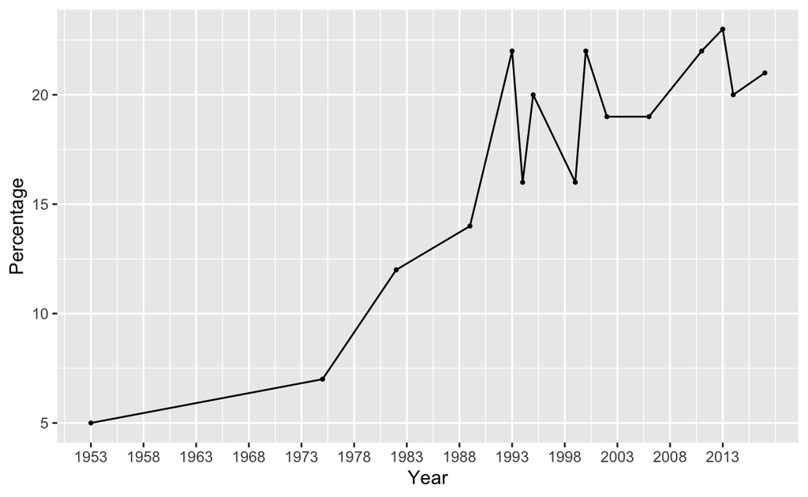

Figure 1: Trend in preferred female leadership over the years

```r
ggplot(data=gender_preference,
       aes( x= year,
            y= share_of_people_who_prefer_female_boss_gallup_2017
         )) +
  geom_line() +
  geom_point(size=0.7) +
  scale_x_continuous(breaks = seq(1953, 2017,
                                  by = 5)) +
  labs(
    x="Year",
    y="Percentage"
       )
```

## Final Note

Make sure to push all your commits and changes to GitHub before submitting the exercise sheet.